# Effects of Ford GoBike User Type, Age, And Gender on the Trip Duration.

## by Saleh Sadek Rekaby

## Investigation Overview

In this investigation, I wanted to look at the characteristics of Users that could be used to predict the Trip duration. The main focus was on the User Type, Age, and Gender.

## Dataset Overview

The data consisted of Trip Duration and attributes of approximately 183500 Ford GoBike Users. The attributes included the User Type, Gender, User Birth Date, as well as additional measurements such as Station location,Trip Start Time - End Time. Some Columns were removed from the analysis due to no need for them, age of User is added, and Trip Duration converted from seconds to Minutesfor more readability.

## Distribution of Trip Duration

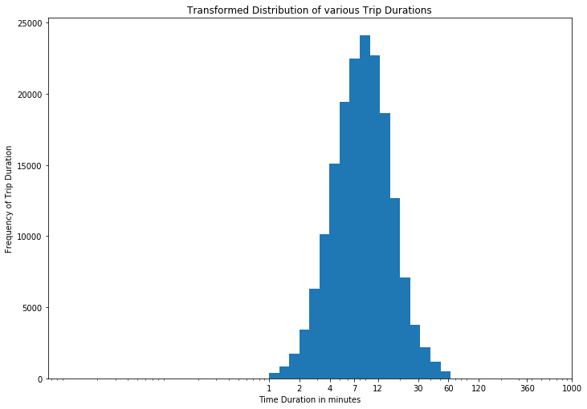

## Distribution of User's Age

Plotting Age view, the majority of user age Distribution is under 45 years.

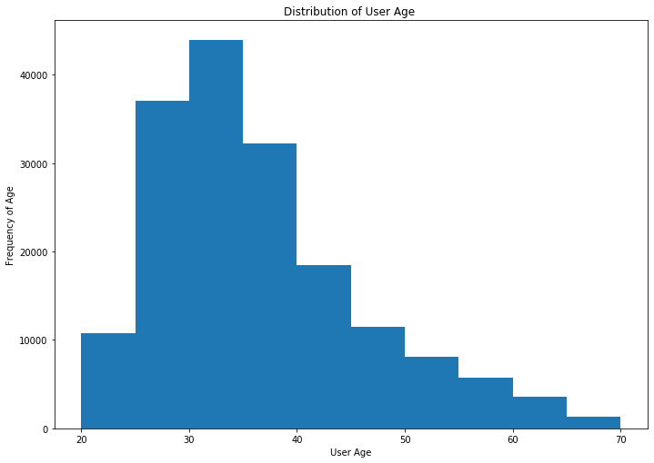

## Type Of Users

Plotting show the majority of user Type are Subscribers.

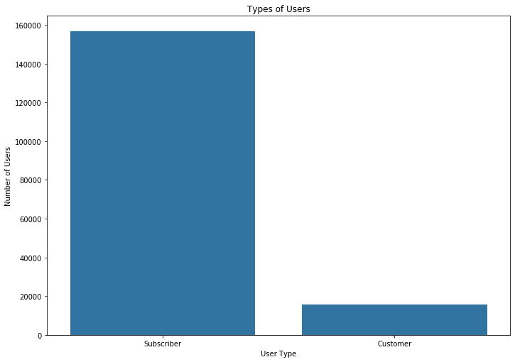

## Gender of Users

This graph show the dominance of male users as a ford gobike users.

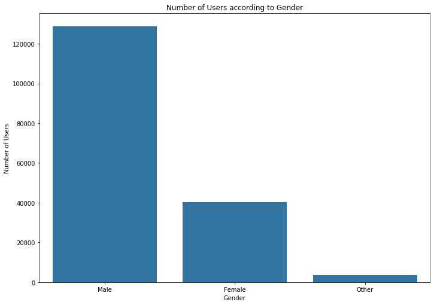

## Effect of Age on the Trip Duration

The age seems to have an effect on Trip Duration, as the age of the user increases, the trip duration decreases.

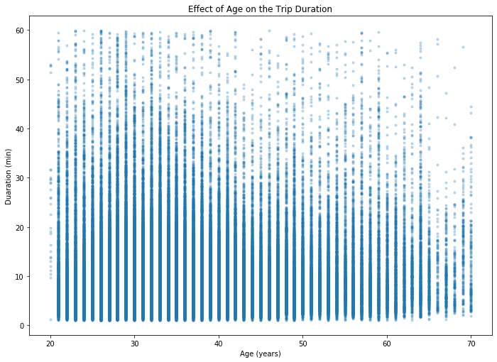

## Effect of User type on the Trip Duration

The Subscribers seems to have low Trip Duration, in spite they represent the majority of ford gobike Users.

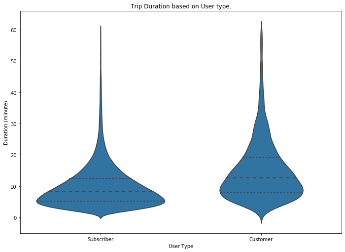

## Trip Duration by Gender and User Type

A high Trip Duration average of Female Customer compared with Male Customer, while the Male Subscribers show the lowest Trip duration average compared with female Subscribers.

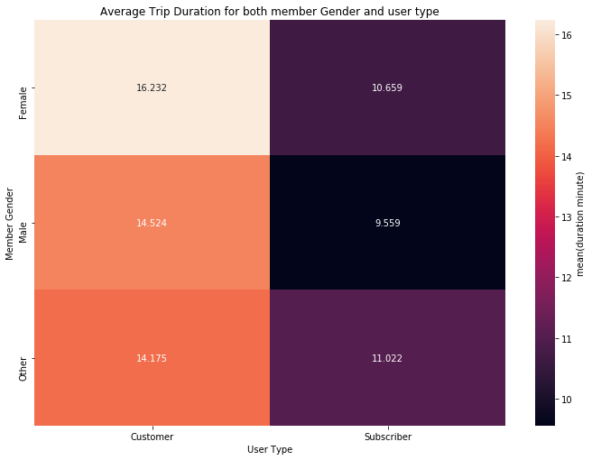

## Trip Duration by Age and User Type

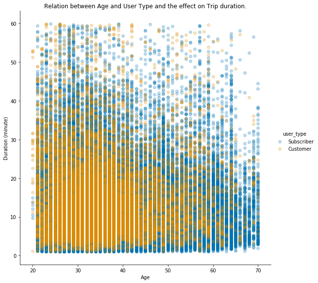